# Using R to figure out which cards to cut from my Cube

Willem Krantz

## Research Questions and Background

Magic the Gathering is a trading card game which has many different formats. For the sake of this project we will be looking at the format called cube. Cube involves selecting cards through out Magic’s history to form your own draftable set. Magic gets printed in sets and each set can be drafted. Draft is a format where each player gets 3 packs, they crack a pack select a card and the pass that pack. Each player builds 40 card decks from their drafted cards and then play in tournament style. My cube is being built to be drafted as standard but also commander. Therefore it is essential that I look at the following…

What cards do I want to cut from my cube?

What color combos are fastest which are slowest?

How can I offset speed so that certain decks don’t dominant the cube?

Here I will break down the cards I have selected for my cube and through analysis gain a deeper insight into what the mana curves for individual colors look like and thus what mana curves for multi-colored decks look like. In a draft setting you want to try and keep a healthy balance of cards and curves. If one color is more powerful than the rest then it is likely that the majority of drafters will try and find themselves in that color. By comparing my cube to a 540 card Vintage cube I will be able to greater understand curves and what cards should be cut of kept based off of card type and mana cost.

## Data Processing

#### Data Intake

```r
knitr::opts_chunk$set(echo = TRUE)

knitr::opts_chunk$set(eval = TRUE)

knitr::opts_chunk$set(include = TRUE)

library(tidyverse)
```

```r
library(readr)
library(ggplot2)
#import data

MyCube<-read_csv("TheCube.csv")
  glimpse(MyCube)
```

```
## Rows: 842
## Columns: 6
## $ Name            <chr> "Myriad Lanscape", "Myriad Lanscape", "Command Tower",…
## $ `Mana Cost`     <chr> "n/a", "n/a", "n/a", "n/a", "n/a", "n/a", "n/a", "n/a"…
## $ Color           <chr> "colorless", "wubrg", "wubrg", "wubrg", "wubrg", "wubr…
## $ `Card Type`     <chr> "Land", "Land", "Land", "Land", "Land", "Land", "Land"…
## $ Rarity          <chr> "Uncommon", "Uncommon", "Common", "Common", "Common", …
## $ `Creature Type` <chr> "n/a", "n/a", "n/a", "n/a", "n/a", "n/a", "n/a", "n/a"…
```

```r
VintageCube<-read_csv("MTGOVintageCube.csv")
  glimpse(VintageCube)
```

```
## Rows: 540
## Columns: 16
## $ name               <chr> "Esper Sentinel", "Giver of Runes", "Mother of Rune…
## $ CMC                <dbl> 1, 1, 1, 1, 1, 1, 2, 2, 2, 2, 2, 2, 2, 2, 2, NA, 2,…
## $ Type               <chr> "Artifact Creature - Human Soldier", "Creature - Ko…
## $ Color              <chr> "W", "W", "W", "W", "W", "W", "W", "W", "W", "W", "…
## $ Set                <chr> "mh2", "mh1", "ulg", "roe", "mb1", "khm", "xln", "m…
## $ `Collector Number` <chr> "12", "13", "14", "47", "260", "35", "1", "10", "11…
## $ Rarity             <chr> "rare", "rare", "uncommon", "rare", "common", "unco…
## $ `Color Category`   <chr> "w", "w", "w", "w", "w", "w", "w", "w", "w", "w", "…
## $ status             <chr> "Owned", "Not Owned", "Not Owned", "Not Owned", "No…
## $ Finish             <chr> "Non-foil", "Non-foil", "Non-foil", "Non-foil", "No…
## $ maybeboard         <lgl> FALSE, FALSE, FALSE, FALSE, FALSE, FALSE, FALSE, FA…
## $ `image URL`        <lgl> NA, NA, NA, NA, NA, NA, NA, NA, NA, NA, NA, NA, NA,…
## $ `image Back URL`   <lgl> NA, NA, NA, NA, NA, NA, NA, NA, NA, NA, NA, NA, NA,…
## $ tags               <chr> NA, NA, "New", "New", NA, NA, "New", NA, "New", NA,…
## $ Notes              <lgl> NA, NA, NA, NA, NA, NA, NA, NA, NA, NA, NA, NA, NA,…
## $ `MTGO ID`          <dbl> 90393, 72398, 12553, 36586, NA, 87393, 65012, 92942…
```

#### Data Wrangling

```r
CMC<-MyCube%>%
  rename(ManaCost=`Mana Cost`)%>%
  mutate(ManaCost= ifelse(ManaCost=="n/a", 0,ManaCost))%>%
  group_by(ManaCost)%>%
  summarise(count=n())
  sample_n(CMC,size=10)
```

| ManaCost | count |
| --- | --- |
| 7 | 13 |
| 8 | 5 |
| 3 | 198 |
| 6 | 33 |
| 5 | 53 |
| 0 | 55 |
| 4 | 119 |
| 1 | 120 |
| 2 | 244 |
| 9 | 2 |

This shows each count for each cmc. The cmc of 0 counts lands as well as 0 cmc cards.

```r
VCMC<-VintageCube%>%
  mutate(CMC= ifelse(is.na(CMC), 0,CMC))%>%
  group_by(CMC)%>%
  summarise(count=n())
  head(VCMC)
```

| CMC | count |
| --- | --- |
| 0 | 171 |
| 1 | 64 |
| 2 | 97 |
| 3 | 82 |
| 4 | 52 |
| 5 | 33 |

here is the same data but for the Vintage cube. I will be comparing their curve to my curve.

# Red Cards

```r
Red<-
  MyCube[MyCube$Color == "r",]
  head(Red)
```

| Name | Mana Cost | Color | Card Type | Rarity | Creature Type |
| --- | --- | --- | --- | --- | --- |
| Forgotten Cave | n/a | r | Land | Uncommon | n/a |
| Smoldering Crater | n/a | r | Land | Common | n/a |
| Fire Diamond | 2 | r | Artifact | Common | n/a |
| Monastery Swiftspear | 1 | r | Creature | Uncommon | Human Monk |
| Akroan Crusader | 1 | r | Creature | Common | Human Soldier |
| Forge Devil | 1 | r | Creature | Common | Devil |

# Green Cards

```r
Green<-
  MyCube[MyCube$Color == "g",]
```

# Black Cards

```r
Black<-
  MyCube[MyCube$Color == "b",]
```

# Blue Cards

```r
Blue<-
  MyCube[MyCube$Color == "u",]
```

# White Cards

```r
White<-
  MyCube[MyCube$Color == "w",]
```

# Colorless Cards

```r
Colorless<-
  MyCube[MyCube$Color == "colorless",]
```

# Red Mana Costs

```r
ManaCostRed<-
  Red%>%
  rename(ManaCost=`Mana Cost`)%>%
  mutate(ManaCost= ifelse(ManaCost=="n/a", 0,ManaCost))%>%
  group_by(ManaCost)%>%
  summarise(count=n())
  head(ManaCostRed)
```

| ManaCost | count |
| --- | --- |
| 0 | 2 |
| 1 | 27 |
| 2 | 36 |
| 3 | 30 |
| 4 | 12 |
| 5 | 6 |

The table shown under Red is identical to the tables of the other colors therefore I chose to only show red. These tables are essential in giving me a visual for what each colors card count is per cmc. This will effectively show me which colors are speedier than others and what colors want to play for the late game. This is huge because the only way for the slow colors to keep up with the fast colors is with disruption. When making cuts I will take this into account as I decide which cards are worthy of staying in versus being removed.

# Black Mana Costs

```r
ManaCostBlack<-
  Black%>%
  rename(ManaCost=`Mana Cost`)%>%
  mutate(ManaCost= ifelse(ManaCost=="n/a", 0,ManaCost))%>%
  group_by(ManaCost)%>%
  summarise(count=n())
```

# Green Mana Costs

```r
ManaCostGreen<-
  Green%>%
  rename(ManaCost=`Mana Cost`)%>%
  mutate(ManaCost= ifelse(ManaCost=="n/a", 0,ManaCost))%>%
  group_by(ManaCost)%>%
  summarise(count=n())
```

# White Mana Costs

```r
ManaCostWhite<-
  White%>%
  rename(ManaCost=`Mana Cost`)%>%
  mutate(ManaCost= ifelse(ManaCost=="n/a", 0,ManaCost))%>%
  group_by(ManaCost)%>%
  summarise(count=n())
```

# Blue Mana Costs

```r
ManaCostBlue<-
  Blue%>%
  rename(ManaCost=`Mana Cost`)%>%
  mutate(ManaCost= ifelse(ManaCost=="n/a", 0,ManaCost))%>%
  group_by(ManaCost)%>%
  summarise(count=n())
```

# Colorless Mana Costs

```r
ManaCostColorless<-
  Colorless%>%
  rename(ManaCost=`Mana Cost`)%>%
  mutate(ManaCost= ifelse(ManaCost=="n/a", 0,ManaCost))%>%
  group_by(ManaCost)%>%
  summarise(count=n())
```

# Finding Mean CMC values for Colors

```r
SumValueRed<-
   Red%>%
   rename(ManaCost=`Mana Cost`)%>%
   mutate(ManaCost= ifelse(ManaCost=="n/a", 0,ManaCost))%>%
   select(ManaCost)
  MeanValueRed<-as.numeric(unlist(SumValueRed))
  mean(MeanValueRed)
```

```
## [1] 2.521368
```

The mean mana value for red cards in my cube is 2.521368 mana. This is a good sign as it means most cards cost around 2 or 3 which is good for a proper curve.

# Joining CMCs for Dimir

```r
  DimirManaCost<-
  full_join(ManaCostBlack, ManaCostBlue, by="count")
  sample_n(DimirManaCost, size=6)
```

| ManaCost.x | count | ManaCost.y |
| --- | --- | --- |
| NA | 38 | 3 |
| 5 | 6 | NA |
| NA | 19 | 1 |
| 4 | 17 | NA |
| NA | 5 | 6 |
| 8 | 1 | NA |

This table shows the combonation of Black and Blue CMC counts, Black is x and Blue is y. I took a random sample of 6 in order to get a spread of each color.

# Creature Detection

```r
Rogues<-
  MyCube%>%
  group_by(`Creature Type`, Color)%>%
  summarise(count=n())%>%
  filter(grepl("Rogue", `Creature Type`, ignore.case=TRUE,))
  head(Rogues)
```

| Creature Type | Color | count |
| --- | --- | --- |
| Elf Rogue | g | 1 |
| Elf Rogue | u | 1 |
| Faerie Rogue | u | 2 |
| Halfling Rogue | b | 1 |
| Halfling Rogue | u | 1 |
| Halfling Rogue | ub | 1 |

This code gives me a count of how many rogues I have and which colors they are. By filtering out the other creatures I can now look at how well tribal synergies will work. Rogues do great in Dimir builds (Blue and Black), so seeing that there are rogues outside of those colors may show me possible cuts. I say possible because if a green rogue is amazing it will be worth keeping in. I will repeat this code for the other tribals synergies in my Cube like Goblins, Humans, Devils, and Halflings.

# 2 Color Pairings and CMC

```r
Boros<-
  MyCube[MyCube$Color == "r"| MyCube$Color == "w",]
  head(Boros)
```

| Name | Mana Cost | Color | Card Type | Rarity | Creature Type |
| --- | --- | --- | --- | --- | --- |
| The Fair Basilica | n/a | w | Land | Common | n/a |
| Forgotten Cave | n/a | r | Land | Uncommon | n/a |
| Smoldering Crater | n/a | r | Land | Common | n/a |
| Marble Diamond | 2 | w | Artifact | Common | n/a |
| Fire Diamond | 2 | r | Artifact | Common | n/a |
| Nahiri, the Lithomancer | 5 | w | Planeswalker | Mythic | n/a |

```r
Izzet<-
  MyCube[MyCube$Color == "r"| MyCube$Color == "u",]


Gruul<-
  MyCube[MyCube$Color == "r"| MyCube$Color == "g",]


Rakdos<-
  MyCube[MyCube$Color == "r"| MyCube$Color == "b",]


Golgari<-
  MyCube[MyCube$Color == "b"| MyCube$Color == "g",]


Azorius<-
  MyCube[MyCube$Color == "w"| MyCube$Color == "u",]


Orzhov<-
  MyCube[MyCube$Color == "w"| MyCube$Color == "b",]


Simic<-
  MyCube[MyCube$Color == "g"| MyCube$Color == "u",]


Selesnya<-
  MyCube[MyCube$Color == "g"| MyCube$Color == "w",]


Dimir<-
  MyCube[MyCube$Color == "u"| MyCube$Color == "b",]
```

Just as with the single color data, this data shows us the CMC’s of all 10 2 color pairings. I only showed the head of boros (red white), but each table looks the same. It lists the card names and their CMC, as well as card type and creature type. This will show me which color pairs are aggro, midrange, or control magic and will give insite as to what should be cut. This data will also be intergral to the 480 card Commander cube as it will show me which cards fit nicely into the Commander archetypes vs those that kinda stink.

# Finding Boros’s Curve

```r
BorosCurve<-
  Boros%>%
  rename(ManaCost=`Mana Cost`)%>%
  mutate(ManaCost= ifelse(ManaCost=="n/a", 0,ManaCost))%>%
  rename(CardType= `Card Type`)%>%
  group_by(ManaCost,CardType,Color)%>%
  summarise(count=n())
  head(BorosCurve)
```

| ManaCost | CardType | Color | count |
| --- | --- | --- | --- |
| 0 | Land | r | 2 |
| 0 | Land | w | 1 |
| 1 | Artifact | r | 1 |
| 1 | Artifact | w | 1 |
| 1 | Creature | r | 7 |
| 1 | Creature | w | 5 |

This table combines all red and white cards (Boros’s color identity), this table was then used to generate the graphics below showing Boros’s mana curve and spread of card types.

# Looping for Random Pack Construction

```r
  RandomPacks<-
    MyCube%>%
    select(Name)
x<-RandomPacks

Packs<-sample_n(x, size=15, replace=FALSE)
replicate(3,Packs)
```

```
## $Name
##  [1] "Kagha, Shadow Archdruid"     "Dreamstalker Manticore"
##  [3] "Duress"                      "Rule of Law"
##  [5] "Archetype of Courage"        "Legion Warboss"
##  [7] "Vedalken Humiliator"         "Energy Flux"
##  [9] "Vampire's kiss"              "Paragon of Modernity"
## [11] "Padeem, Conul of Innovation" "Footfall Crater"
## [13] "Ash Barrens"                 "Defiant Strike"
## [15] "Charcoal Diamond"
##
## $Name
##  [1] "Kagha, Shadow Archdruid"     "Dreamstalker Manticore"
##  [3] "Duress"                      "Rule of Law"
##  [5] "Archetype of Courage"        "Legion Warboss"
##  [7] "Vedalken Humiliator"         "Energy Flux"
##  [9] "Vampire's kiss"              "Paragon of Modernity"
## [11] "Padeem, Conul of Innovation" "Footfall Crater"
## [13] "Ash Barrens"                 "Defiant Strike"
## [15] "Charcoal Diamond"
##
## $Name
##  [1] "Kagha, Shadow Archdruid"     "Dreamstalker Manticore"
##  [3] "Duress"                      "Rule of Law"
##  [5] "Archetype of Courage"        "Legion Warboss"
##  [7] "Vedalken Humiliator"         "Energy Flux"
##  [9] "Vampire's kiss"              "Paragon of Modernity"
## [11] "Padeem, Conul of Innovation" "Footfall Crater"
## [13] "Ash Barrens"                 "Defiant Strike"
## [15] "Charcoal Diamond"
```

## My DATA

#### The Curve

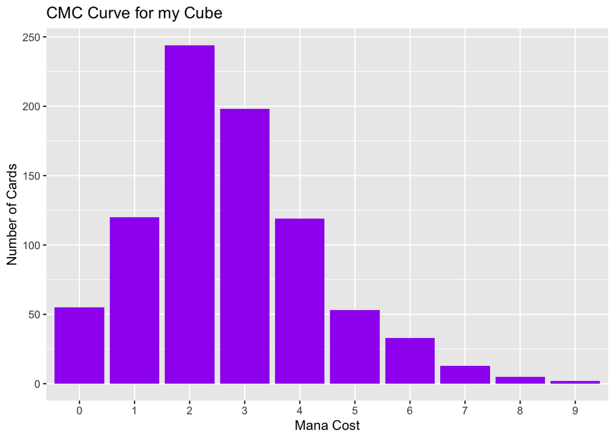

```r
ggplot(CMC) +
  geom_bar(aes(x = ManaCost, y = count), stat = "identity", fill="purple")+ggtitle("CMC Curve for my Cube")+labs(y="Number of Cards", x="Mana Cost")
```

This histogram shows the “Mana Curve” of my cube. A Mana Curve is a curve of each mana cost. This curve is huge for showing players what to look to draft. My curve looks really good as there are mostly 2 and 3 cost cards in the cube. When I make cuts this initial curve will help guide me with which cards I choose to cut.

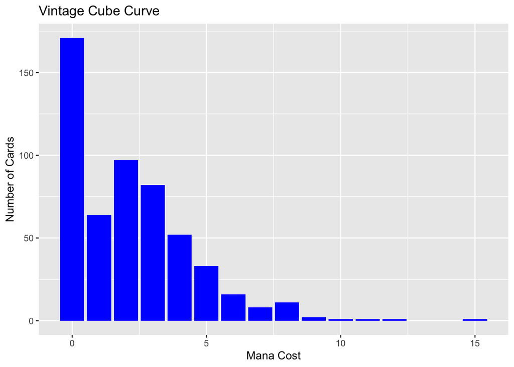

```r
ggplot(VCMC)+
  geom_bar(aes(x= CMC, y=count), stat="identity", fill="blue")+ggtitle("Vintage Cube Curve")+labs(y="Number of Cards", x="Mana Cost")
```

## CMC for Red

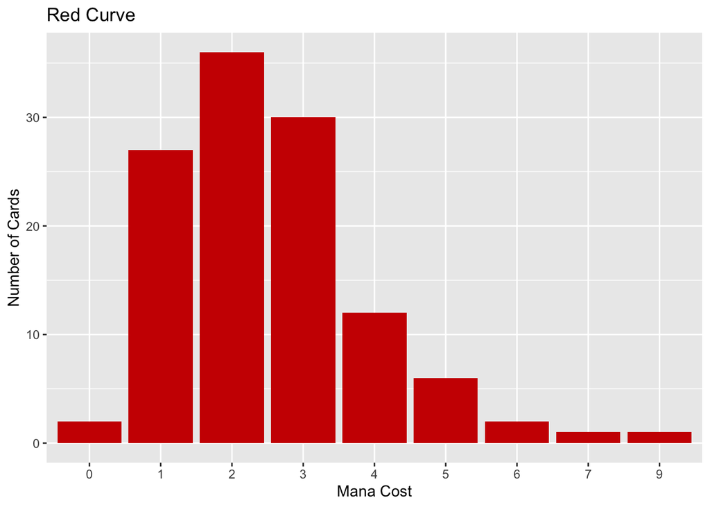

```r
ggplot(ManaCostRed)+
  geom_bar(aes(x= ManaCost, y= count), stat="identity", fill="red3")+ggtitle("Red Curve")+labs(y="Number of Cards", x="Mana Cost")
```

## Boros Card Spread

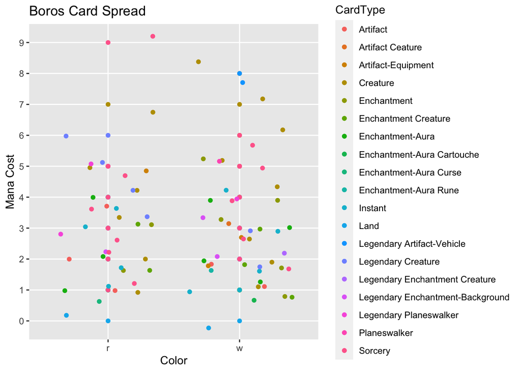

```r
ggplot(BorosCurve)+
  geom_point(aes(x=Color, y=ManaCost, color=CardType))+
  geom_jitter(aes(x=Color,y=ManaCost, color=CardType))+ggtitle("Boros Card Spread")+labs(y="Mana Cost",x="Color")
```

## BorosCurve

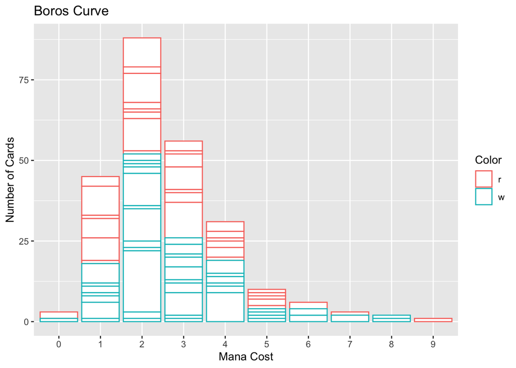

```r
ggplot(BorosCurve)+
  geom_bar(aes(x=ManaCost, y= count, color=Color), stat="identity",fill="white")+ggtitle("Boros Curve")+labs(y="Number of Cards", x="Mana Cost")
```

Boros Card Spread and Boros Curve give us insight into what the 2 color pairing of red and white looks like. The BCS chart shows the spread of CMC for each color and what card types make up the different CMCs. The Boros Curve graph shows the curve of the combination of colors as well as splits each bar into individual color so that way we know if it is an even split or not. Based on the Boros Curve graph we can see that Boros is a fast color with many 2 drops and 1 drops. The table for BorosCurve shows the spread of each card type which could prove helpful for making cuts. The same graphs will be made for each color and each 2 color combo.

## Further Analysis

As you can see I did not analyze every curve (each color and each 2 color combo). As this is done for a project there was no need for me to repeat my code at this time. Each other curve and color/card spread will be coded identically to my current code. Through this lovely source I will easily be able to cut cards accordingly. As stated early my cube will be multi functional so at this moment I need to cut 362 cards to get down to the 480 cards for my commander cube and cut 482 cards to get down to the 360 needed for my standard cube. Since all my data is now readily accesible I will be able to mess around and figure out good deck lists for my archetypes as well as chop out the unneeded excess. The might just have to start calling me The Butcher.

## Conclusion

In order to get to the ideal play experience it looks like I will be leveling the curves quite a bit. I need to get each color down to 60 ish cards for the 360 standard cube. The cuts will start with the higher costed cards and then will become a battle between the 1,2, and 3 drops to see who stays and who goes. The best thing about this way on analyzing my cube is that I get to visually see which colors are going to makeup different archetypes. Magic has 3 main builds, Aggro(fast), Midrange(medium pace), and Control(Slow your opponent to a halt). With my data I am now able to see which colors fit which archetypes and how draftees will likely build their decks. It also gives insight into whether a color may prove to be too powerful. Blue has a lot of counter magic which is good, but could just shut out a red aggro deck. This info must be taken into mind when I make cuts and decisions about what stays and goes.